# Test a Perceptual Phenomenon

### Analyzing the Stroop Effect

Perform the analysis in the space below. Remember to follow [the instructions](https://docs.google.com/document/d/1-OkpZLjG_kX9J6LIQ5IltsqMzVWjh36QpnP2RYpVdPU/pub?embedded=True) and review the [project rubric](https://review.udacity.com/#!/rubrics/71/view) before submitting. Once you've completed the analysis and write-up, download this file as a PDF or HTML file, upload that PDF/HTML into the workspace here (click on the orange Jupyter icon in the upper left then Upload), then use the Submit Project button at the bottom of this page. This will create a zip file containing both this .ipynb doc and the PDF/HTML doc that will be submitted for your project.

(1) What is the independent variable? What is the dependent variable?

#### An independent variable: it is a variable that stands alone and isn't changed by the other variables

#### An dependent variable: It is variable that depends on other factors

#### (Independent variable) causes a change in (Dependent Variable) and it isn't possible that (Dependent Variable) could cause a change in (Independent Variable).

#### In a stroop effect experiment ,the color of the worlds is independent and reaction time to the name the font color is dependent .

(2) What is an appropriate set of hypotheses for this task? Specify your null and alternative hypotheses, and clearly define any notation used. Justify your choices.

$H_{0}$ :$μ1$ = $μ2$  
$H_{1}$ :$μ1$ $\neq$ $μ2$

null hypotheses is the population of congruent color of time is the same of the population mean for the incongruent color in time to reading it thats mean there is no difference.

(3) Report some descriptive statistics regarding this dataset. Include at least one measure of central tendency and at least one measure of variability. The name of the data file is 'stroopdata.csv'.

```python
# Perform the analysis here
import pandas as pd
import matplotlib.pyplot as plt
%matplotlib inline
import math
import numpy as np
from scipy import stats
df = pd.read_csv('stroopdata.csv')
df.head()
```

|  | Congruent | Incongruent |
| --- | --- | --- |
| 0 | 12.079 | 19.278 |
| 1 | 16.791 | 18.741 |
| 2 | 9.564 | 21.214 |
| 3 | 8.630 | 15.687 |
| 4 | 14.669 | 22.803 |

```python
#caculate the difference
df['diff'] = df['Incongruent'] - df['Congruent']
df['diff']
```

```
0      7.199
1      1.950
2     11.650
3      7.057
4      8.134
5      8.640
6      9.880
7      8.407
8     11.361
9     11.802
10     2.196
11     3.346
12     2.437
13     3.401
14    17.055
15    10.028
16     6.644
17     9.790
18     6.081
19    21.919
20    10.950
21     3.727
22     2.348
23     5.153
Name: diff, dtype: float64
```

```python
#caculate the mean average
Congruent_mean =df['Congruent'].mean()
Incongruent_mean =df['Incongruent'].mean()
```

```python
Congruent_mean,Incongruent_mean
```

```
(14.051124999999999, 22.015916666666666)
```

```python
#caculate the standard devation
std=df['diff'].std()
```

```python
std
```

```
4.8648269103590556
```

(4) Provide one or two visualizations that show the distribution of the sample data. Write one or two sentences noting what you observe about the plot or plots.

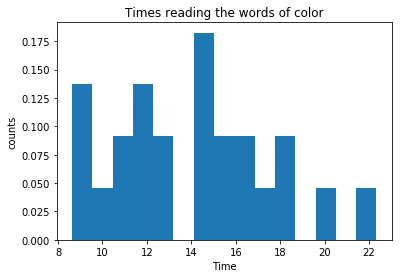

```python
# Build the visualizations here

plt.hist(df['Congruent'],density=1,  bins=15)
plt.title('Times reading the words of color')
plt.xlabel('Time')
plt.ylabel('counts')
plt.show()
```

#### The chart above is about histogram, its clarify the congruent color about how spending time in each color world to read and how long is take on reading each one. looking at the chart is shows that most congruent color range between 8 to 15

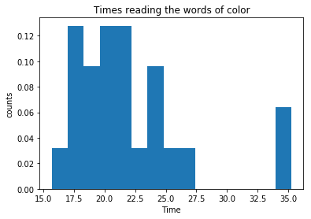

```python
plt.hist(df['Incongruent'],density=1,  bins=15)
plt.title('Times reading the words of color')
plt.xlabel('Time')
plt.ylabel('counts')
plt.show()
```

#### The chart above shows the incongruent color about how spending time in each color world to read and how long is take on reading each one. looking at the chart is shows that most incongruent color range between 16 to 26 which spend extra time related to congruent color

```
([array([ 5.,  6.,  7.,  4.,  1.,  1.,  0.,  0.,  0.,  0.]),
  array([ 0.,  0.,  1.,  7.,  6.,  6.,  2.,  0.,  0.,  2.])],
 array([  8.63  ,  11.2925,  13.955 ,  16.6175,  19.28  ,  21.9425,
         24.605 ,  27.2675,  29.93  ,  32.5925,  35.255 ]),
 <a list of 2 Lists of Patches objects>)
```

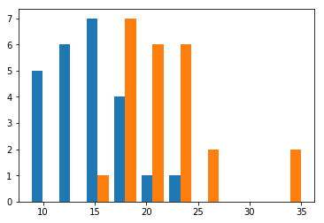

```python
import seaborn as sns,numpy as np
x=df['Congruent']
y=df['Incongruent']

plt.hist([x, y],label=['x', 'y'])
```

#### explain more why you are using a t-test, instead of a z-test

We used a t-test, instead of a z-test because we have few number of data less than 100 while z-test is used in large samples.

#### What task are you trying to accomplish or discover?

I'm trying to discover that if the congruent color or Incongruent has same time on read depending on the color or not

```python
#legnth of data
n=len(df)
```

```python
# Perform the statistical test here
difference_mean =  Incongruent_mean - Congruent_mean
```

```python
#calculate the standard error

#divide each std by square root of the legnth of sample
se= std / math.sqrt(n)

#take the square root for standard devation
sed= math.sqrt(se**2.0)
```

```python
#finding t-value
t_value = difference_mean / sed
t_value
```

```
8.020706944109957
```

```python
#calculate t-score and p-value directly
t,p=stats.ttest_rel(df['Incongruent'],df['Congruent'])
t,p
```

```
(8.020706944109957, 4.1030005857111781e-08)
```

```python
#degree of freedom
df = n-1
df
```

```
23
```

```python
#finding critical value
alpha =0.05
cv=stats.t.ppf(1-alpha , df)
cv
```

```
1.7138715277470473
```

(6) Optional: What do you think is responsible for the effects observed? Can you think of an alternative or similar task that would result in a similar effect? Some research about the problem will be helpful for thinking about these two questions!